WA Energy System Adequacy Analysis - Grid-Scale Batteries

AR-PSTStage 6 Topic 4-2

# WA Energy System Adequacy Analysis - Grid-Scale Batteries

The Australian National University

**Team**: Marnie Shaw, Laura Jones, Kylie Catchpole, Heather Logie, Roshini Barrett, and Noah Dimonti

**Project partners**: AEMO WA, Western Power, NEOEN, Synergy

This project assesses the current and future state of WA energy system, focusing on the adequacy of grid-scale batteries. Two main deliverables of the project includes, a statistics pack of the battery fleet behaviour analysis and a modelling of the fleet adequacy risk indicators in the future.

Deliverables

**D2**

Statistics Pack (complete)

**D3**

Risk Indicators (in progress)

Updated 20 Nov 2026

## Section 1Grid reliance on the fleet

### Peak demand met by the fleet

The total capacity of ESRs (Electric Storage Resources) in WA has increased rapidly over the past 3 years. As more batteries are commissioned, the grid may rely on them more to meet peak demand. The following plot shows how this reliance has changed over the past two years. Because operational demand has stayed relatively stable, **the growth in reliance does not appear to be driven by changes in demand**. The median share of peak demand in ESROI window met by the fleet has increased from under 5% in the first half of 2025 to around 15% by winter 2026, with a dip to about 10% in April 2026. Not only are the batteries relied on more by the grid, but **they are also being utilised more during peak time.** This trend holds despite new batteries being commissioned (more capacity) and peak demand staying relatively stable.

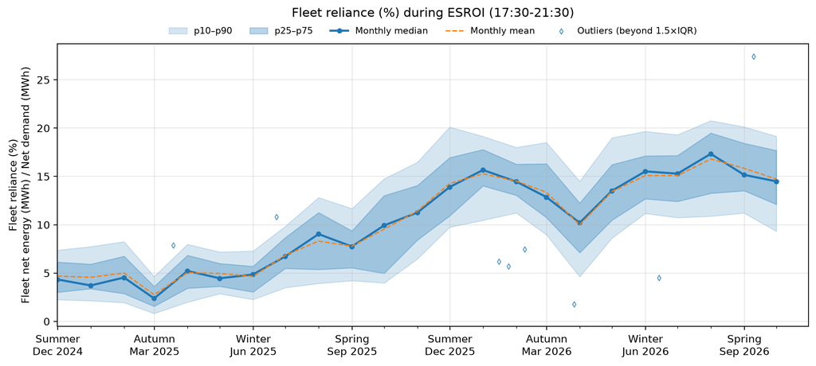

## Section 2The fleet obligation and charge level

### Fleet SOC at ESROI window

In the WEM, market participants may have an obligation to make their capacity available during peak times, and sometimes at other times as well. **All currently operating ESRs have a capacity obligation during the Electric Storage Resource Obligation Interval (ESROI) window.** The amount they must provide is their Reserve Capacity Obligation Quantity (RCOQ), which differs from battery to battery.

To meet its obligation, a battery must make its RCOQ available through the quantities in its offers. There is no specific guideline on how much SOC a battery needs to meet its obligation. However, **the rule change proposed by Energy Policy WA (EPWA) and AEMO would allow AEMO to direct the fleet to hold a certain level of charge during Lack of Reserve (LOR) events**, which are considered system stress events.

Although the batteries' day-to-day obligation does not specify what state of charge (SOC) they should hold, batteries differ from other generators in that their supply is limited in duration. Hence, it is important to look at how much energy the fleet has at the start of the ESROI. The aggregate fleet SOC at 17:30 has a median of 72.7%, and SOC was below 50% on 5.1% of days across about 2 years of data.

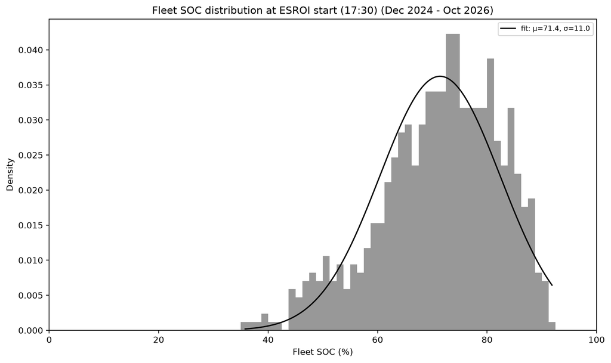

| Statistic | Fleet SOC at 17:30 |
| --- | --- |
| Days | 681 (1 Dec 2024 – 31 Oct 2026) |
| Mean | 71.4% |
| Median | 72.7% |
| Standard deviation | 11.0% |
| Minimum | 35.8% (1 Sep 2025) |
| Maximum | 91.9% (11 Feb 2025) |
| Days below 50% | 35 (5.1%) |
| Days below 40% | 5 (0.7%) |

*Fleet SOC counts only the batteries reporting a charge level; a battery that is offline (reading 0 and offering nothing) is left out for those intervals.*

## Section 3Charge on stress days

The fleet appears to have sufficient charge on a typical day, which emphasises the importance of looking at days of high system stress. Defining these "stress days" is the first step in assessing the fleet's ability to fulfil its role. However, stress days can be defined in different ways, such as high-demand days, low spare capacity days, or with other metrics. Among those, AEMO market advisories are the ones that market participants must follow. When AEMO announces a Lack of Reserve (LOR) or Lack of Reserve Capacity (LRC) event, batteries were expected to be prepared for the stress events in the past, and will soon be expected to have a certain charge level as per the rule change.

### AEMO market advisories

In the last several years, stress events occurred more frequently during summer, as expected. However, some events also occurred during winter and the shoulder seasons.

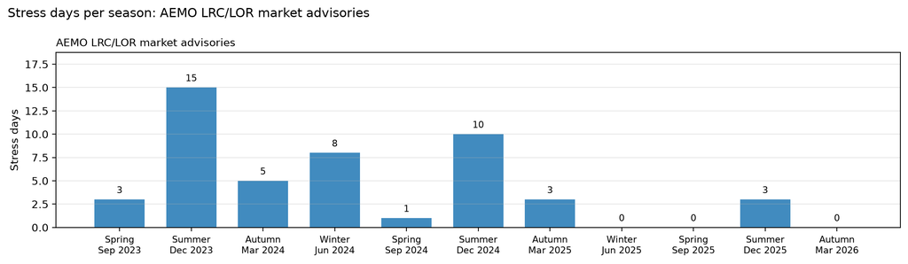

### Fleet SOC on stress days

The fleet SOC during stress events mostly falls within the range of SOC on normal days. The lowest charge was observed on 28 January 2025, when the fleet SOC was 32% at midday. Apart from this day, most stress-day SOC values at midday are distributed above the median normal-day SOC. This might be related to the fact that the batteries prepare for a higher charge level once AEMO publishes the notice.

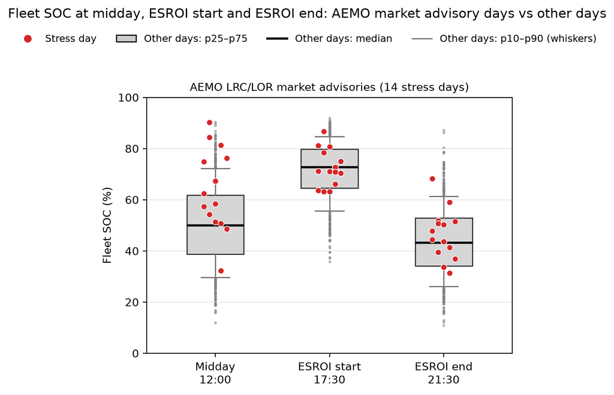

## Section 4Fleet owners' operating strategies

Although the pattern varies between owners, all batteries typically charge between 9am and 3pm and discharge during the evening peak (the ESROI window). This is consistent with both arbitrage and their obligation to provide capacity during the ESROI.

### Power distribution by time-of-day

Different charge-discharge cycles can be observed across owners. Synergy batteries typically have a small morning peak discharge around 6-7am, in addition to the routine midday charge and evening peak discharge, whereas Neoen batteries only have the midday-charge and peak-discharge patterns.

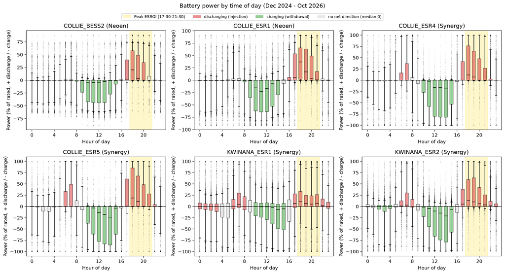

### Battery charge–discharge cycles

Neoen and Synergy batteries follow different charge–discharge patterns: Neoen batteries cycle mainly in the evening, while Synergy's also run a morning cycle. Apart from KWINANA_ESR1, which cycles more than once a day, the other batteries only cycle around 50–60% of their maximum capacity each day.

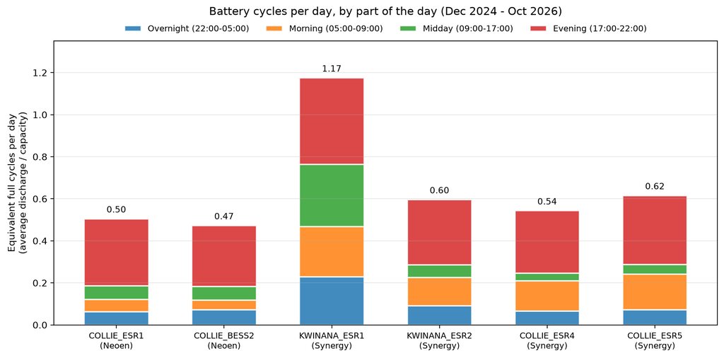

*Cycles = average energy discharged per day ÷ battery capacity (MWh), so 1.0 is one full battery's worth of discharge.*

### Battery charging synchronisation

Given the difference in how batteries manage their charging-discharging cycle, there is a chance that batteries charging-discharging activities are not synchronised. This may become a concern especially during the window time prior to ESROI, where the fleet should be prepared for peak time, instead of cancelling each other's energy out.

We measure how much of the batteries' activity cancels out (some batteries charging while others discharge) using the following calculation:

$$ \text{Cancelling out (\%)} = \left(1 - \frac{\text{Energy reaching the grid}}{\text{All battery activity}}\right) \times 100 $$

- **Energy reaching the grid (MWh):** in each 5-minute interval, the absolute value of the fleet's total injection minus its total withdrawal, converted to energy (MW × 5 minutes = MWh) and summed over the month (or hour of day).
- **All battery activity (MWh):** in each 5-minute interval, the fleet's total injection plus its total withdrawal, converted to MWh and summed in the same way.

For example, if battery A discharges 100 MW while battery B charges 30 MW, total activity is 130 MW and 70 MW reaches the grid, so 1 − 70 ÷ 130 = 46% cancels out.

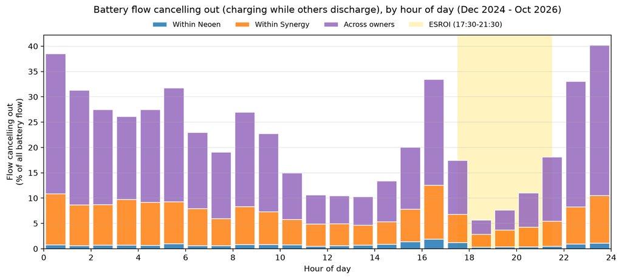

Most batteries discharge synchronously during the ESROI window, especially in the first couple of hours, and charge synchronously at midday. However, there is a lot of cancelling-out activity about an hour before the ESROI, as well as at night after the peak ends and around midnight/early morning.

## Section 5Prices and forecasts

Since batteries now **set the energy price around 90% of the time**, their influence within the market is significant. Understanding their adequacy and behaviour therefore involves understanding what drives their decisions. When constructing their offers, batteries are required to follow the Offer Construction Guideline, which is based on the price forecast. Hence, **analysing prices and their forecasts is key to explaining battery behaviour.**

### Energy price median and standard deviation trends

The median daily price has risen from $75/MWh (Dec 2023–Sep 2024) to $100/MWh (Dec 2025–Sep 2026), while daily price variability fell sharply in late 2024 and has stayed low since.

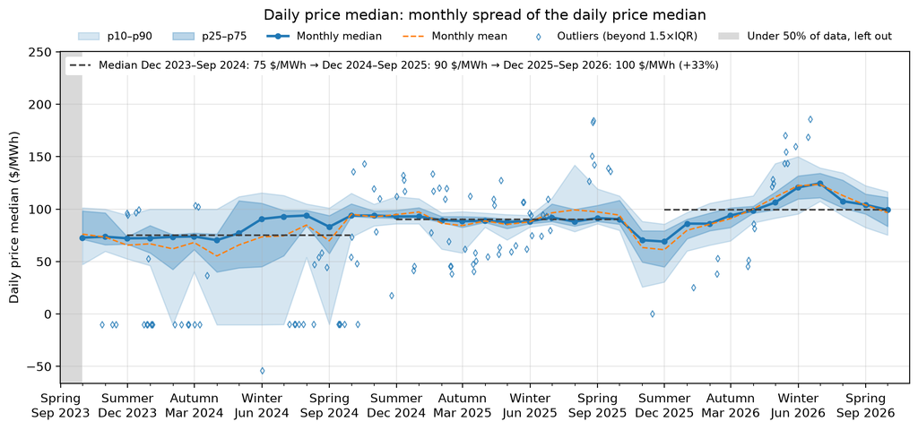

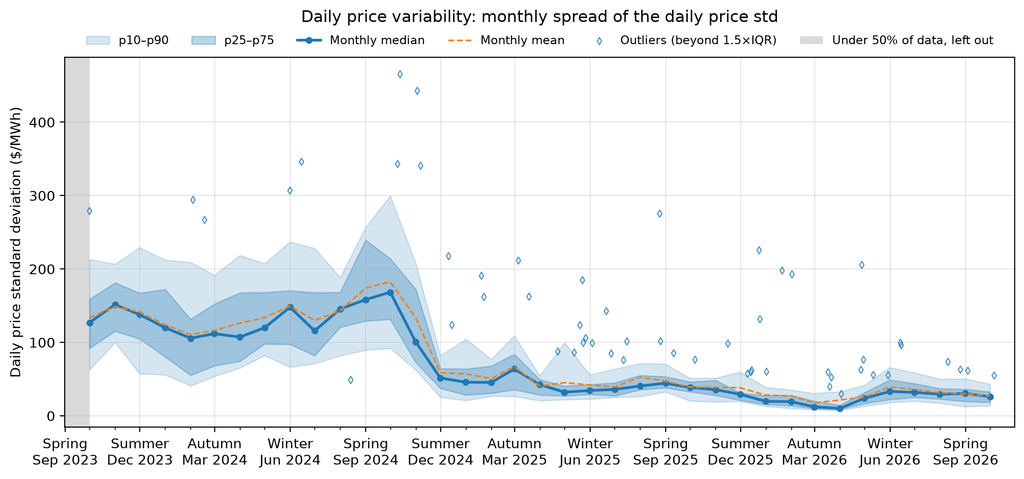

Prices influence the batteries' behaviour, but batteries also influence prices. The drop in price variability in late 2024 may be associated with new batteries entering the WEM.

### Price forecast error over the years

The forecast error band across the whole day has narrowed over the years. The following plot shows the 4-hour-ahead forecast, but the same trend is observed at other lead times.

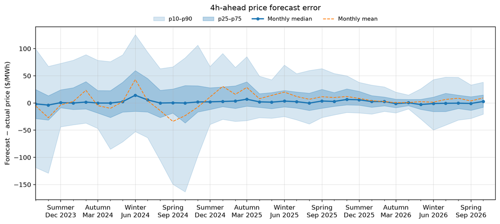

Over the ESROI window specifically, the forecast error pattern has shifted in the past 3 years: from underestimating peak prices to overestimating them, especially at longer lead times.

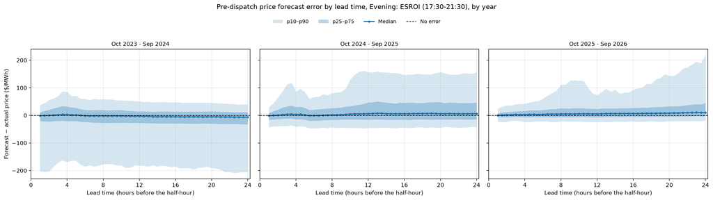

### Price forecast error by lead time and time of day

At midday, the spread of forecast error stays consistent across lead times. During the ESROI, by contrast, the forecast increasingly over-estimates the price the further ahead it looks.

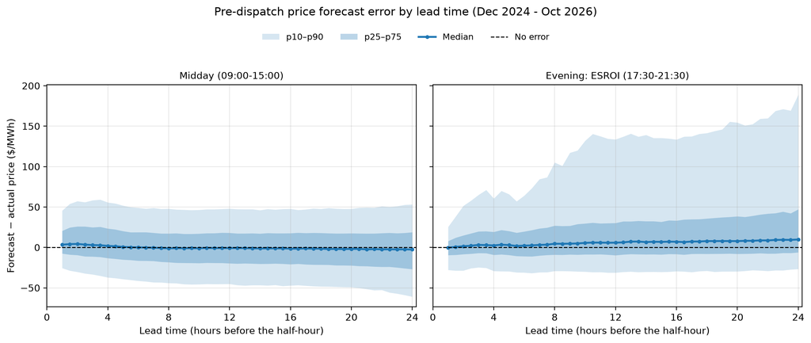

### Offer construction guideline

Batteries construct their offers from the price forecast, following the Offer Construction Guideline, and these offers determine when they charge and discharge. Their adequacy (how much energy they hold going into the ESROI) therefore depends on their bidding behaviour. At the same time, because batteries set most energy prices, the price forecast is itself shaped by their bidding behaviour. This creates a feedback loop that did not exist before batteries entered the market. As a result, battery adequacy cannot be assessed from SOC alone, it depends on how this loop between forecasts, offers and prices plays out, especially when the forecast is not accurate.

Additionally, the Offer Construction Guideline itself can be open to interpretation. Different battery owners are able to strategise their bidding differently without violating the guideline. **This creates another layer of complexity in the way that we could model the system and assess its adequacy in the future.**

[figure not shown]

https://www.erawa.com.au/sites/default/files/24549/wem-offer-construction-guidelines-clean-version.PDF

### Objectives and plan

The overall objective of D3 is to help AEMO determine when they should be concerned about system security (now and into the future). There are three steps in the path:

- Use our understanding of actual battery behaviour and the bid construction guidelines to build a model of battery behaviour
- Build this into a system dynamics model
- Model future scenarios from the ESOO to determine where the system security breakpoints are

[figure not shown]